# 12 Mapper: the general case

> “The real voyage of discovery consists not in seeking new landscapes, but in having new eyes.”  
> — Marcel Proust, in “In Search of Lost Time”

We have already seen two specific mapper-like constructions:

- classical Mapper, based on a filter function and overlapping intervals;
- Ball Mapper, based on balls around landmark points.

The local `TDAmapper.jl` API makes the general pattern explicit: a mapper algorithm is a combination of

1. a cover of the data;
2. a refinement rule for each cover element;
3. a nerve construction that turns the refined cover into a graph.

The beauty of this decomposition is that each step can be changed independently. That gives us a whole family of Mapper-like algorithms rather than a single fixed recipe.

## 12.1 The three building blocks

### 12.1.1 Covering step

Examples of covers include:

- overlapping intervals in the image of a filter function;
- fixed-radius balls around landmarks;
- adaptive covers whose radius depends on local density.

In classical Mapper, the cover lives in the image of a filter function. In Ball Mapper, the cover lives directly in the metric space through balls around landmarks.

### 12.1.2 Refinement step

Once we have a raw cover, we may refine each element further:

- `DBscan` clusters each cover element into connected dense pieces;
- `Trivial()` keeps each cover element as a single node.

This is where “connectedness” enters the discrete picture: in the classical Reeb-graph story we would take connected components, but in data analysis we often replace that step by a clustering method.

### 12.1.3 Nerve step

Finally, we build a graph from the refined cover:

- `SimpleNerve()` adds an edge whenever two cover elements overlap;
- more restrictive nerve constructions can require larger intersections or weighted overlaps.

So the full algorithm is: cover, refine, then take a nerve.

## 12.2 Creating a mapper directly

The generic `mapper` function takes one object for each of those stages:

```julia
using MetricSpaces
using MetricSpaces.Datasets
using TDAmapper
using TDAmapper.DomainCovers
using TDAmapper.Refiners
using TDAmapper.Nerves
```

```julia
X_demo = annulus(300)
L_demo = farthest_points_sample_ids(X_demo, 30)

M_demo = mapper(
    X_demo,
    EpsilonBall(X = X_demo, L = L_demo, epsilon = 0.2),
    Trivial(),
    SimpleNerve(),
)

M_demo
```

```
Mapper graph with 30 vertices and 29 edges
```

That is exactly the pattern Ball Mapper uses under the hood. Writing it this way makes it easier to see what can be customized and why.

## 12.3 Interpreting Mapper graphs

Whatever choices we make, the output is still a graph, and we need to know how to read it:

- nodes represent local groups of data points;
- edges connect groups that overlap;
- connected components suggest distinct macroscopic pieces of the data;
- loops suggest circular or toroidal structure;
- branches suggest flares, bifurcations, or tree-like behavior.

Coloring the nodes by a statistic of the underlying data often adds another layer of meaning to the graph.

## 12.4 Example: a noisy figure-eight

```julia
using CairoMakie
using TDAplots
```

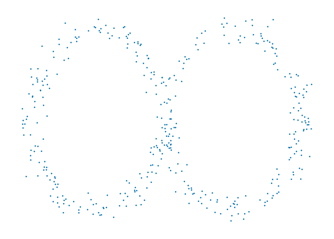

```julia
X = add_noise(figure_eight(400; r = 1.0), 0.08)
metricspace_plot(X, markersize = 4)
```

We now build two mapper graphs using the same landmarks but different radii:

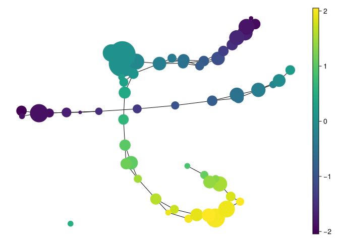

```julia
L = farthest_points_sample_ids(X, 60)

M_small = mapper(
    X,
    EpsilonBall(X = X, L = L, epsilon = 0.25),
    Trivial(),
    SimpleNerve(),
)

mapper_plot(M_small, node_values = node_colors(M_small, first.(X)))
```

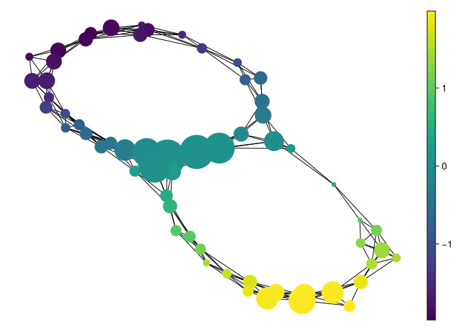

```julia
M_large = mapper(
    X,
    EpsilonBall(X = X, L = L, epsilon = 0.4),
    Trivial(),
    SimpleNerve(),
)

mapper_plot(M_large, node_values = node_colors(M_large, first.(X)))
```

## 12.5 Choosing parameters

There is no universal recipe, but a few heuristics help:

- **Coverage**: every point should belong to at least one cover element.
- **Overlap**: if cover elements barely overlap, the graph becomes disconnected.
- **Resolution**: fine covers reveal more detail but also more noise.
- **Stability**: features that survive across a range of parameters are more trustworthy.

That last point is the mapper version of the persistence philosophy: do not trust a single parameter choice more than the structure that persists across several of them.